[figure not shown]

# Test Technique Data Scientist : Multi-classification

# Objectif

L'objectif de ce test est de modéliser la variable "target" fournie dans un jeu de données nommé "train.csv", pour ensuite réaliser sa prédiction sur des individus contenus dans le jeu "test.csv".

# Étude exploratoire des variables à disposition

Les variables explicatives du jeu de données ne sont pas documentées et leur relation avec la variable cible est donc purement spéculatif.

L'étude des variables portera donc uniquement sur leur qualité et leur exploitabilité pour la modélisation.

Les critères utilisés pour évaluer l'exploitabilité d'une variable sont les suivants :

- **Intersection et inclusion des jeux de données d'entraînement et de test** :
  - Les modalités présentes dans les variables catégorielles du jeu de test doivent être en grande partie présentes dans le jeu d'entraînement afin que les techniques d'encodage utilisées pour l'entraînement restent valides pendant la phase de test.
  - On définit l'intersection comme la métrique quantifiant le pourcentage de modalités présentes à la fois dans le jeu d'entraînement et le jeu de test, tandis que l'inclusion est le pourcentage de modalités du jeu de test présentes dans le jeu d'entraînement.
  - Une inclusion élevée nous garantit que les techniques d'encodage fonctionneront pendant la phase de test.
  - Une intersection élevée nous garantit que l'encodage est pertinent.
- **Entropie des variables catégorielles** :
  - Nous souhaitons que les variables puissent expliquer des comportements différents représentés par la variable cible. Les variables à entropie extrêmement faible sont trop homogènes et donc n'apportent pas d'information significative pour permettre de discriminer les individus selon la variable cible.
- **Complétude des données** :
  - Comme pour l'entropie, les variables dont la très grande majorité des entrées sont manquantes ne permettent pas d'apporter une information significative pour la modélisation.

Nous allons commencer par une analyse de la complétude des données.

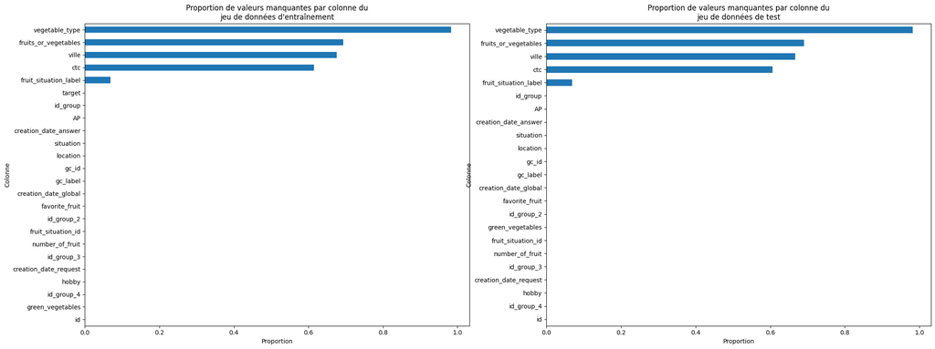

```python
import pandas as pd
import seaborn as sns
import matplotlib.pyplot as plt
%matplotlib inline

train = pd.read_csv("../data/train.csv")
test = pd.read_csv("../data/test.csv")

plt.subplot(1, 2, 1)
train.isna().mean().sort_values().plot(kind = 'barh')
plt.title("Proportion de valeurs manquantes par colonne du\njeu de données d'entraînement")
plt.xlabel("Proportion")
plt.ylabel("Colonne")

plt.subplot(1, 2, 2)
test.isna().mean().sort_values().plot(kind = 'barh')
plt.title("Proportion de valeurs manquantes par colonne du\njeu de données de test")
plt.xlabel("Proportion")
plt.ylabel("Colonne")


fig = plt.gcf()
fig.set_size_inches(25, 9)
```

D'après les graphes ci-dessus, nous remarquons que 4 variables ("vegetable_type", "fruits_or_vegetables", "ville", "ctc") contiennent **plus de 60% de valeurs manquantes**.

Regardons maintenant les niveaux d'intersection, d'inclusion et d'entropie des variables du jeu de données.

|  | intersection | inclusion | entropy |
| --- | --- | --- | --- |
| id | 0.000000 | 0.000000 | 1.000000 |
| AP | 1.000000 | 1.000000 | 0.002266 |
| creation_date_answer | 0.011768 | 0.023295 | 0.995018 |
| situation | 1.000000 | 1.000000 | 0.020211 |
| ctc | 1.000000 | 1.000000 | 0.074981 |
| location | 0.980000 | 0.989899 | 0.397357 |
| gc_id | 1.000000 | 1.000000 | 0.146160 |
| gc_label | 1.000000 | 1.000000 | 0.146160 |
| creation_date_global | 0.278830 | 0.435599 | 0.934883 |
| id_group | 0.273683 | 0.428994 | 0.936299 |
| id_group_2 | 0.280888 | 0.437997 | 0.934951 |
| favorite_fruit | 1.000000 | 1.000000 | 0.057997 |
| fruit_situation_id | 1.000000 | 1.000000 | 0.165860 |
| fruit_situation_label | 1.000000 | 1.000000 | 0.165860 |
| fruits_or_vegetables | 1.000000 | 1.000000 | 0.074403 |
| number_of_fruit | 0.900000 | 0.900000 | 0.083765 |
| id_group_3 | 0.870270 | 0.938228 | 0.602132 |
| creation_date_request | 0.011662 | 0.023089 | 0.995031 |
| hobby | 1.000000 | 1.000000 | 0.007480 |
| id_group_4 | 0.273662 | 0.428967 | 0.936103 |
| ville | 0.568600 | 0.738971 | 0.210784 |
| green_vegetables | 1.000000 | 1.000000 | 0.008680 |
| vegetable_type | 1.000000 | 1.000000 | 0.010112 |

Pour l'analyse suivante, nous regarderons également le nombre de modalités uniques pour chaque colonne du jeu de données d'entraînement :

|  | Nombre de modalités uniques |
| --- | --- |
| id | 25000 |
| AP | 2 |
| creation_date_answer | 24278 |
| situation | 8 |
| ctc | 2 |
| location | 99 |
| gc_id | 12 |
| gc_label | 12 |
| creation_date_global | 15680 |
| id_group | 15844 |
| id_group_2 | 15675 |
| favorite_fruit | 2 |
| fruit_situation_id | 22 |
| fruit_situation_label | 21 |
| fruits_or_vegetables | 2 |
| number_of_fruit | 9 |
| id_group_3 | 872 |
| creation_date_request | 24280 |
| hobby | 3 |
| id_group_4 | 15831 |
| ville | 564 |
| green_vegetables | 2 |
| vegetable_type | 6 |
| target | 4 |

À partir de ce tableau et du graphique précédents, nous avons décidé **d'écarter** les variables suivantes pour la modélisation:

- La variable **"ville"**, en plus d'avoir un taux de valeurs manquantes et un nombre de modalités élevés, a un taux d'intersection et d'inclusion faible. Il n'est donc pas intéressant de l'encoder.

|  | Nombre de modalités uniques |
| --- | --- |
| ville | 564 |

- La variable **"AP"** a une entropie extrêmement faible car elle est composée à 99.6% de la valeur "False".
- Les variables **"id", "id_group", "id_group2" et "id_group4"** ont des taux d'inclusion et intersection extrêmement faible et plus d'avoir un nombre de modalités très élevé (>= 15000).

|  | Nombre de modalités uniques |
| --- | --- |
| id | 25000 |
| id_group | 15844 |
| id_group_2 | 15675 |
| id_group_4 | 15831 |

- La variable **"id_group3"** a un taux d'inclusion intéressant mais son nombre de modalités unique est trop elevé (872). Il aurait pu être intéressant de ne garder que les modalités les plus présentes mais même si nous ne gardons que les 100 modalités les plus présentes, les taux d'inclusion et d'intersection sont trop faibles pour que la variable soit intéressante.
- La variable **"creation_date_request"** est identique à la variable **"creation_date_answer"** dans plus de 99.5% des individus. Nous ne gardons que "creation_date_answer" dans la suite.
- La variable **"green_vegetables"** a une entropie trop faible car elle est composée à 98% de la valeur "False". De plus, la présence d'une valeur False dans cette variable implique l'apparition d'une valeur manquante dans la variable **"vegetables_types"** qui se retrouve par conséquent avec 98% de valeurs manquantes également. C'est pourquoi ces deux variables seront écartées de la modélisation.

| green_vegetables / vegetable_type | almostgreen | green | NA | notsogreen | prettygreen | salad | verygreen |
| --- | --- | --- | --- | --- | --- | --- | --- |
| False | 0 | 0 | 24564 | 0 | 0 | 0 | 0 |
| True | 4 | 227 | 22 | 35 | 10 | 133 | 5 |

- La variable **"hobby"** a également une entropie trop faible car composée à 98.6% de la modalité "football".
- La variable **"fruit_situation_label"** est redondante avec la variable **"fruit_situation_id"** car l'une est l'identifiant de l'autre. Nous allons garder la variable "fruit_situation_id" dans la suite.

# Feature Engineering

À partir des variables temporelles "creation_date_answer", "creation_date_global", nous allons récupérer **le mois et le jour de la semaine** de ces dates car nous supposons que le jeu de données provient d'une enquête concernant la consommation de fruits et légumes et nous supposons que la saison et le jour de la semaine pourraient avoir un impact sur cette consommation. Nous confirmerons cela post-modélisation.

De plus, nous allons **calculer le temps en mois** entre "creation_date_global" et "creation_date_answer" car nous supposons que l'ancienneté du client aurait un impact sur sa consommation de fruits et légumes (Les individus les plus jeunes étant les moins susceptibles de consommer des aliments verts, par exemple).

Les variables à valeur manquantes sont toutes catégorielles, **nous allons donc créer une catégorie "inconnue"** pour ensuite les encoder via les techniques de **One-Hot et Target encoding.**

Le tout est implémenté en utilisant **l'API Pipeline de scikit-learn** pour garantir la reproductibilité des résultats et avoir une API finale **"production-ready"**.

# Modélisation

Par contrainte de temps, nous allons modéliser uniquement le problème via un algorithme **LightGBM** (Gradient Boosting). Cependant, l'API utilisée pour construire la pipeline de Feature Engineering et Modélisation prévoit une option pour modifier le type d'algorithme pour la modélisation, ainsi que la grille d'hyperparamètres à utiliser.

Les variables retenues pour la modélisation sont :

- `'situation'`
- `'ctc'`
- `'gc_label'`
- `'favorite_fruit'`
- `'fruit_situation_id'`
- `'fruits_or_vegetables'`
- `'location'`
- `'number_of_fruit'`
- `'creation_date_answer'`
- `'creation_date_global'`

La recherche d'hyperparamètres optimaux est effectuée par **"Random Search"** car plus efficace que la Grid Search **à budget d'itérations fixé**. Le critère de sélection d'hyperparamètres est la **"weighted log loss"** définie ci-dessous :

$$ \text{Weighted Log Loss} = - \left( \frac{\sum_{i=1}^{N} w_{i} . \sum_{j=1}^{M} y_{ij} \ln p_{ij}}{\sum_{i=1}^{M} w_{i}} \right) $$

où :

- $M$ est le nombre de classes.
- $N$ est le nombre d'individus.
- $p_{ij} est la probabilité d'appartenance à la classe $j$ pour l'individu $i$.
- $w_i$ est le poids associé à l'individu en fonction de sa classe. $ w_i = 10^{y_i} \text{ où } y_i = 0, 1, 2, 3$.

Enfin, comme **la variable cible est très fortement déséquilibrée**, nous allons forcer le modèle à prioriser les classes minoritaires pendant l'entraînement du modèle LightGBM à l'aide de l'argument **`class_weight = "balanced"`**.

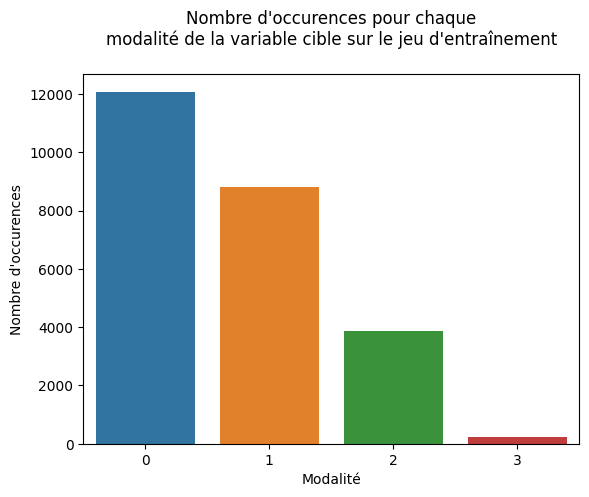

```python
sns.countplot(x = train['target']);
plt.title("Nombre d'occurences pour chaque\nmodalité de la variable cible sur le jeu d'entraînement\n")
plt.xlabel("Modalité")
plt.ylabel("Nombre d'occurences");
```

```python
import pandas as pd
from itertools import product
from IPython.display import display, Markdown
from joblib import load, dump

# Pipeline
from sklearn.pipeline import Pipeline
from dstoolbox.pipeline import DataFrameFeatureUnion

# Encodage
from sklearn.base import BaseEstimator, TransformerMixin
from sklearn.preprocessing import OneHotEncoder, OrdinalEncoder
from sklearn.impute import SimpleImputer
from category_encoders import TargetEncoder

# Evaluation et interprétabion
from sklearn.model_selection import train_test_split, RandomizedSearchCV, learning_curve
from sklearn.metrics import log_loss, f1_score, make_scorer
import shap

def weighted_log_loss(y_true, y_pred):
    y_weights = 10**y_true
    return log_loss(y_true, y_pred, sample_weight=y_weights)

# Modèle
from lightgbm import LGBMClassifier


train = pd.read_csv("../data/train.csv")
test = pd.read_csv("../data/test.csv")

feature_retenus = [
    # À one hot encoder puis target encoder
    'situation',
    'ctc',
    'gc_label',
    'favorite_fruit',
    'fruit_situation_id',
    'fruits_or_vegetables',
    'location',
    # Custom encoders
    'number_of_fruit', # encoder -1, 0 ou >=1
    'creation_date_answer', # extraire mois et jour de la semaine
    'creation_date_global', # calculer ancienneté
]

train = train.set_index('id')[feature_retenus + ['target']]
test = test.set_index('id')[feature_retenus]

class MultiClassTargetEncoder(BaseEstimator, TransformerMixin):
    """
    L'implémentation du Target Encoder de la librairie category_encoders ne prend pas en charge les variables cibles multi-classes.
    Cette version du Target Encoder va instancier un encodeur pour chaque modalité de la variable cible, et concaténer les encodages obtenus.
    Nous obtenons n_targets * n_features colonnes au total.
    """
    def __init__(self, columns = None):
        super().__init__()
        self.columns = columns
        return None

    def fit(self, X, y):
        y = pd.get_dummies(y)
        if self.columns is not None:
            X = X[self.columns]

        self.encoders = [TargetEncoder(cols = self.columns, min_samples_leaf=2, smoothing=0.99).fit(X, y[y_i]) for y_i in y.columns]
        return self

    def transform(self, X):
        if self.columns is not None:
            X = X[self.columns]

        return pd.concat([encoder.transform(X).rename(columns = {col : 'te_{}_{}'.format(col, i) for col in self.columns}) for i, encoder in enumerate(self.encoders)], axis = 1)


class OneHotEncoderPandas(BaseEstimator, TransformerMixin):
    """
    Cette implémentation du OneHotEncoder renvoie un DataFrame en sortie et non un array numpy. Ceci est fait pour garantir la
    traçabilité des variables et faciliter l'interprétation du modèle dans la suite.
    """
    def __init__(self, columns = None):
        super().__init__()
        self.columns = columns
        self.ohe = OneHotEncoder(handle_unknown= "ignore", sparse = False)

    def fit(self, X, y = None):

        if self.columns is not None:
            X = X[self.columns]

        self.ohe.fit(X)

        # Récupération des noms de colonnes + categories pour l'interprétabilité
        # Ex : "situation_-1", "situation_10", etc..
        self.feature_category_pairs = []

        for i, feature in enumerate(self.ohe.feature_names_in_):
            feature_category = product([feature], self.ohe.categories_[i])

            for pair in feature_category:
                self.feature_category_pairs.append("{}_{}".format(*pair))

        return self

    def transform(self, X):
        if self.columns is not None:
            X = X[self.columns]

        return pd.DataFrame(self.ohe.transform(X), columns = self.feature_category_pairs)


class NumberFruitEncoder(BaseEstimator, TransformerMixin):
    """
    Ce transformer va encoder la variable "number_of_fruit" en :
     * -1 : la valeur reste inchangée
     * 0 : la valeur reste inchangée
     * 1 : si la valeur est supérieure ou égale à 1.
    """
    def __init__(self) -> None:
        super().__init__()

    def fit(self, X, y = None):
        return self

    def transform(self, X):
        return X['number_of_fruit'].apply(lambda x: x if x <= 1 else 1)


class DateFeatureExtractor(BaseEstimator, TransformerMixin):
    """
    Ce transformer va extraire le mois et le jour de la semaine des colonnes "creation_date_answer" et "creation_date_global"
    et calculer "l'ancienneté" de l'individu en mois à partir de la différence entre ces deux colonnes.
    """
    def __init__(self) -> None:
        super().__init__()

    def fit(self, X, y = None):
        return self

    def transform(self, X):

        if not isinstance(X, pd.DataFrame):
            X = X.to_frame().T

        X = X.copy()
        X['creation_date_answer'] = pd.to_datetime(X['creation_date_answer'])
        X['creation_date_global'] = pd.to_datetime(X['creation_date_global'])

        X['answer_month'] = X['creation_date_answer'].dt.month
        X['answer_day'] = X['creation_date_answer'].dt.weekday
        X['anciennete_mois'] = (X['creation_date_answer'] - X['creation_date_global']).dt.days // 30

        return X[['answer_month', 'answer_day', 'anciennete_mois']]

# variables à encoder par One Hot + Target Encoding
to_ohe = [
    'situation',
    'ctc',
    'gc_label',
    'favorite_fruit',
    'fruit_situation_id',
    'fruits_or_vegetables',
    'location',
]

# Les sorties des 4 transformers seront concaténées dans un DataFrame
feature_pipeline = DataFrameFeatureUnion([
        ("OneHotEncoding", OneHotEncoderPandas(columns = to_ohe)),
        ("MultiClassTargetEncoding", MultiClassTargetEncoder(columns = to_ohe)),
        ("NumberofFruitEncoding", NumberFruitEncoder()),
        ("DateFeatures", DateFeatureExtractor())
])
```

```python
X = train.drop("target", axis = 1)
y = train['target']

X_train, X_test, y_train, y_test = train_test_split(X, y, test_size=0.2, random_state=1)

def build_pipeline(model):
    """
    Fonction pour construire la pipeline de prédiction, le paramètre model doit être une instance d'un modèle type scikit-learn.
    """
    ML_pipeline = Pipeline(
        [
            ('FeatureEngineering', feature_pipeline),
            ("Model", model)
        ]
    )

    return ML_pipeline

param_lgbm = {
    "Model__n_estimators": np.logspace(1, 3, 20).round().astype(int),
    "Model__learning_rate": np.logspace(-5, 2, 10),
    "Model__num_leaves": np.linspace(10, 100, 10).round().astype(int),
    "Model__max_depth": [2, 5, 10, 20, 30, None],
    "Model__lambda_l1": np.logspace(-5, 2, 10),
    "Model__lambda_l2": np.logspace(-5, 2, 10),
    "Model__bagging_fraction": np.logspace(-2, 0, 10)
}

pipeline = build_pipeline(LGBMClassifier(silent = True, random_state=1, class_weight = "balanced"))

# La recherche d'hyperparamètres est effectuée par "Random Search" car plus efficace que la Grid Search à nombre d'itérations fixé.
# Le critère de sélection est la "weighted log loss".

weighted_log_loss_scorer = make_scorer(weighted_log_loss, greater_is_better=False, needs_proba=True)

rcv = RandomizedSearchCV(pipeline, param_distributions=param_lgbm, n_iter = 100, cv = 4, n_jobs=-1, scoring = weighted_log_loss_scorer, verbose = 3, error_score="raise", random_state = 1)
rcv.fit(X_train, y_train)

dump(rcv.best_estimator_, "best_model.joblib")
print(rcv.best_params_)
```

```
Fitting 4 folds for each of 100 candidates, totalling 400 fits
```

```
[LightGBM] [Warning] bagging_fraction is set=0.046415888336127774, subsample=1.0 will be ignored. Current value: bagging_fraction=0.046415888336127774
[LightGBM] [Warning] lambda_l1 is set=100.0, reg_alpha=0.0 will be ignored. Current value: lambda_l1=100.0
[LightGBM] [Warning] lambda_l2 is set=2.782559402207126, reg_lambda=0.0 will be ignored. Current value: lambda_l2=2.782559402207126
{'Model__num_leaves': 10, 'Model__n_estimators': 43, 'Model__max_depth': 5, 'Model__learning_rate': 0.0774263682681127, 'Model__lambda_l2': 2.782559402207126, 'Model__lambda_l1': 100.0, 'Model__bagging_fraction': 0.046415888336127774}
```

# Évaluation et Interprétation du modèle final

Le modèle final obtient les performances suivantes:

```python
def performance(model):
    performances = {
        "Dataset" : ['Train', 'Test'],
        "F1" : [
            f1_score(y_train, model.predict(X_train), average = "micro"),
            f1_score(y_test, model.predict(X_test), average = "micro")
            ],
        "Weighted Log Loss" : [
            weighted_log_loss(y_train, model.predict_proba(X_train)),
            weighted_log_loss(y_test, model.predict_proba(X_test))
            ]
    }

    return pd.DataFrame(performances).set_index("Dataset")

model = load("../models/best_model.joblib")
performance(model)
```

| Dataset | F1 | Weighted Log Loss |
| --- | --- | --- |
| Train | 0.7504 | 0.390869 |
| Test | 0.6904 | 1.086951 |

La performance F1 n'indique pas de sur-apprentissage excessif, cependant la pénalité appliquée à la weighted log loss pénalise fortement le modèle sur le jeu de test, ce qui montre que le modèle n'est finalement pas si performant sur les classes minoritaires.

```
<module 'matplotlib.pyplot' from 'c:\\Users\\Pierre\\anaconda3\\envs\\testda\\lib\\site-packages\\matplotlib\\pyplot.py'>
```

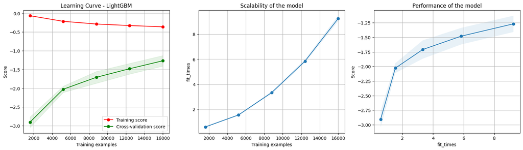

```python
from utils import plot_learning_curve

estimator = model
plot_learning_curve(
    estimator,
    title = "Learning Curve - LightGBM",
    X = X_train,
    y = y_train,
    cv=5,
    n_jobs=4,
    scoring=weighted_log_loss_scorer,
)
```

La performance du modèle par validation croisée augmente presque linéairement entre 5000 et 16000 échantillons, ce qui laisse penser que la performance du modèle pourrait continuer à croître s'il avait accès à davantage de données d'entraînement.

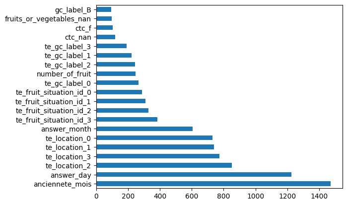

```python
feat_importances = pd.Series(
    data = model._final_estimator.feature_importances_,
    index = model._final_estimator.feature_name_
    )

feat_importances.nlargest(20).plot(kind = 'barh');
```

Les variables "answer_month" et "answer_day", extraite à partir de la variable "creation_date_answer", et les variables "anciennete_mois" et "location" sont parmis les variables les plus utilisées par le modèle pour faire ses prédictions. Ce résultat n'est pas surprenant car ce sont les variables qui ont le plus de variabilité parmi les variables explicatives.

```python
model = load("../models/best_model.joblib")
explainer = shap.TreeExplainer(model['Model'])
shap_values = explainer.shap_values(model['FeatureEngineering'].transform(X_train))
```

Feature Importances pour la classe 0

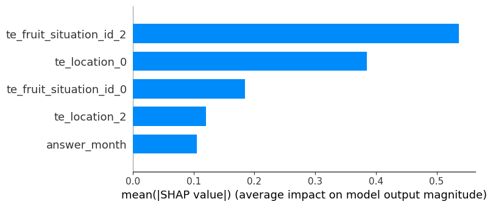

Feature Importances pour la classe 1

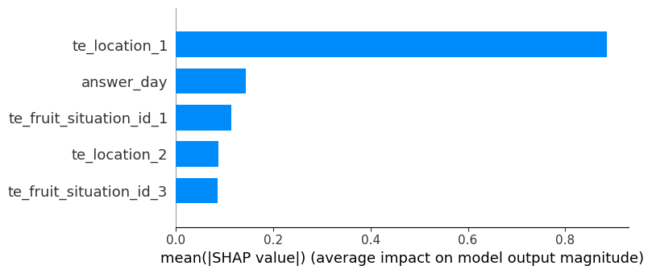

Feature Importances pour la classe 2

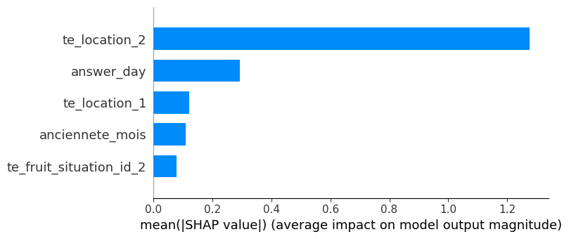

Feature Importances pour la classe 3

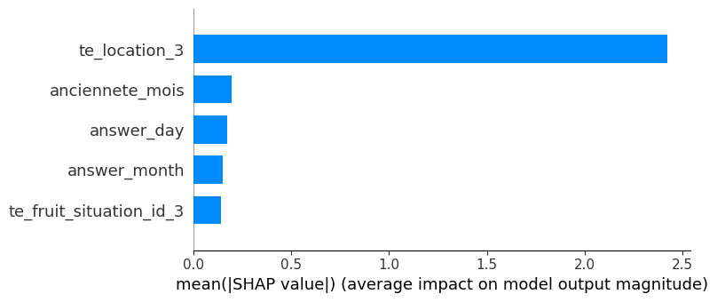

```python
display(Markdown("# Feature Importances pour la classe 0"))
shap.summary_plot(shap_values[0], model['FeatureEngineering'].transform(X_train), plot_type="bar", max_display=5)

display(Markdown("# Feature Importances pour la classe 1"))
shap.summary_plot(shap_values[1], model['FeatureEngineering'].transform(X_train), plot_type="bar", max_display=5)

display(Markdown("# Feature Importances pour la classe 2"))
shap.summary_plot(shap_values[2], model['FeatureEngineering'].transform(X_train), plot_type="bar", max_display=5)

display(Markdown("# Feature Importances pour la classe 3"))
shap.summary_plot(shap_values[3], model['FeatureEngineering'].transform(X_train), plot_type="bar", max_display=5)
```

# Prédiction sur le jeu de test

```python
from joblib import load

model = load("../models/best_model.joblib")

y_pred = model.predict_proba(test)

for i in range(4):
    test['Prediction_{}'.format(i)] = y_pred[:, i]

test[['Prediction_{}'.format(i) for i in range(4)]].to_csv("predictions.csv", header = False)
```

# Annexe : Pistes n'ayant pas abouti

**Calibration du modèle** à l'aide [Scikit Learn](https://scikit-learn.org/stable/modules/calibration.html)

- Résultats moins bons qu'avec le modèle de base.

Création d'une **fonction objectif "custom"** pour LGBM

- Le calcul du gradient et de la hessienne de la weighted log loss en utilisant la libraire [JAX](https://github.com/google/jax) était trop coûteux en mémoire (16gb de RAM nécessaires).

# Annexe : Code pour calculer les métriques d'intersection, inclusion et entropie utilisé dans l'évaluation de l'exploitabilité des variables explicatives :

```python
intersections = {}

for col in test.columns:
    intersections[col] = [len(set(train[col]).intersection(set(test[col]))) / len(set(train[col]).union(set(test[col])))]

intersect = pd.DataFrame(intersections).T.rename(columns={0 : "intersection"})

inclusions = {}

for col in test.columns:
    inclusions[col] = [len(set(train[col]).intersection(set(test[col]))) / len(test[col].unique())]

inclusion = pd.DataFrame(inclusions).T.rename(columns={0 : "inclusion"})

import numpy as np

entropies = {}

for col in test.columns:
    pk = train[col].value_counts(normalize=True, dropna = False).values
    entropy = - (pk * np.log(pk) / np.log(len(train))).sum()
    entropies[col] = [entropy]

entropy = pd.DataFrame(entropies).T.rename(columns={0 : "entropy"})

metrics = pd.concat([intersect, inclusion, entropy], axis = 1)

def highlight_low_inclusion(value):
    if value > 0.95:
        return 'background-color: lightgreen'
    else:
        return 'background-color: pink'

def highlight_low_entropy(value):
    if value > 0.1:
        return 'background-color: lightgreen'
    else:
        return 'background-color: pink'

output = metrics.style.applymap(highlight_low_inclusion, subset=pd.IndexSlice[:, ['intersection', 'inclusion']])\
             .applymap(highlight_low_entropy, subset=pd.IndexSlice[:, ['entropy']])
```